# Affine transformations of sf objects

Manipulating simple features in `sf` is sorta simple, sorta not…

```r
knitr::opts_chunk$set(error = TRUE, message = TRUE)
```

## Packages

```r
library(sf)
library(dplyr)
library(wk)
```

## A simple square

Just to get things set up let’s make a simple square.

```r
square <- (st_polygon(list(matrix(c(-1, -1, 1, -1, 1, 1, -1, 1, -1, -1),
                                 5, 2, byrow = TRUE))) * 0.5 + c(1, 0)) %>%
  st_sfc()

tm_shape(square) +
  tm_borders(col = "red") +
  tm_grid()
```

[output not shown]

```
Error in tm_shape(square): could not find function "tm_shape"
```

## Simple transformations

In the code above, we made a polygon and multipled it by 0.5, then added `c(1,0)` to it. This had the effect of scaling it by 0.5 andthen translating it by the vector
$$\left[\begin{array}{c}1\\0\end{array}\right]$$

These unlikely looking operations are [perfectly valid](https://r-spatial.github.io/sf/articles/sf3.html#affine-transformations), although they feel a bit ‘off’.

Even more unlikely is that you can *multiply an `sf` object by a matrix*…

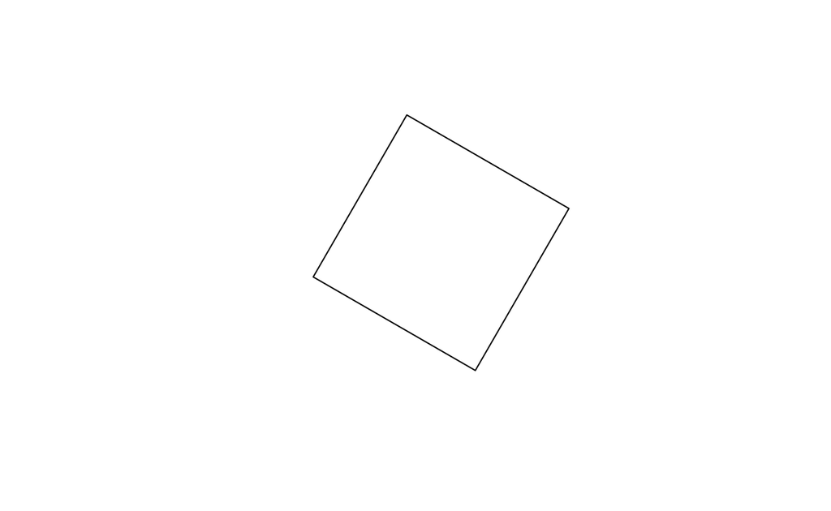

```r
ang <- pi / 6
mat <- matrix(c(cos(ang), -sin(ang),
                sin(ang),  cos(ang)), 2, 2, byrow = TRUE)
(square * mat) %>%
  plot()
```

This is very handy… but probably also a bad idea! Because you have to post-multiply by the matrix, the sense of many [affine transformations](https://en.wikipedia.org/wiki/Affine_transformation) is reversed and construction of the matrix is not ‘by the book’. *Usually* the affine transformation matrix $\mathbf{A}$ for an anti-clockwise rotation by angle $\theta$ around the origin, would be

$$\mathbf{A} =
\left[\begin{array}{cc}
\cos\theta & -\sin\theta \\
\sin\theta & \cos\theta
\end{array}\right]$$

Here, because we are post-multiplying the rotation will be in the other direction… and to rotate anti-clockwise, you use the $-\mathbf{A}=\mathbf{A}^T$

This means that if you are doing any serious affine transforming of `sf` shapes at a low-level in R spatial, I recommend either writing some wrapper functions that generate and apply the necessary matrices on the fly, or, probably better yet, using the [`wk` package](https://paleolimbot.github.io/wk/) which has proper support for affine transformations.